# Final Project

Dylan Maddux

2023-12-07

### Claim Date Creation

```r
#create a new variable which is the claimdate (we will add 1 to day assuming coverage starts at the beginning of the month)
memberfiltered <- member %>%
  mutate(MindateCoverage = paste(year, month, 1 , sep = "-"))

#This code takes a while to run
memberfiltered <- memberfiltered %>%
  group_by(id) %>%
  mutate(MaxdateCoverage = max(ymd(MindateCoverage)))
        #Mindate = min(ymd(Mdate)))
#The code below removes the necessity for this (speeding up computation time)

#since the data set is in chronological order, removing duplicates keeps the first entries
#which is why Mindate is now accurate
memberfiltered <- memberfiltered %>%
  distinct(id, .keep_all = TRUE)
```

### Prepare Data to Create Age Variable

```r
#add date and column rows (used for age calculation)
visits <- claims %>%
  mutate(year = year(as.Date(date)), month = month(as.Date(date)))

#join data sets and create age variable
visits <- left_join(x = visits, y = memberfiltered, by = c("id"))

#remove unnecessary columns
visits <- select(visits, -5:-8)
```

### Create Age Variable

```r
#create new data set with age using entries containing a birth visit (we use this to filter out invalid age)
ageatbirthdf <- visits %>%
  filter(ICD %in% "O80" | ICD %in% "O82") %>%
  mutate(ageAtBirth = interval(ymd(DoB),ymd(date))/years(1)) %>%
  filter(ageAtBirth >= 18 & ageAtBirth <= 40.1)

id <- ageatbirthdf$id
ageAtBirth <- ageatbirthdf$ageAtBirth
ageatbirthdf <- data.frame(id,ageAtBirth)

#this left join will filter out people who has a birth outside our desired age range
visits <- left_join(x = ageatbirthdf, y = visits, by = c("id"))

#create new data set that shows all ids who have valid coverage
#notice how we use intervals from the min and max coverage dates
covereddf <- visits %>%
  filter(ICD %in% "O80" | ICD %in% "O82") %>%
  mutate(backinterval = interval(ymd(MindateCoverage),ymd(date))/months(1),
         frontinterval = interval(ymd(date),ymd(MaxdateCoverage))/months(1)) %>%
  filter(backinterval >= 8.5 & frontinterval >= 2.5)
```

### Clean Up Data Set

```r
id <- covereddf$id
backinterval <- covereddf$backinterval
frontinterval <- covereddf$frontinterval
covereddf <- data.frame(id,backinterval,frontinterval)

#this filters out all of the ids with improper coverage
visits <- left_join(x = covereddf, y = visits, by = c("id"))

#Add Boolean variables
visits <- visits %>%
  group_by(id) %>%
  mutate(VaginalBirth = "O80" %in% ICD,
         Depression = "F32.3" %in% ICD,
         Anxiety = "F41.8" %in% ICD,
         Migraine = "G43.4" %in% ICD,
         OpioidPrescription = "J0745" %in% ICD)
```

### Delivery Variable

```r
#Add delivery variable
delivery <- ifelse(visits$VaginalBirth == TRUE, "Vaginal_Birth","Cesarean_Section")
visits$DeliveryType = delivery

#to show unique individuals
visits <- visits%>%
  filter(ICD %in% "O80" | ICD %in% "O82")
```

### Data Manipulation/Recoding

```r
#cleaning up the data frame
visits$backinterval = ceiling(backinterval)
visits$frontinterval = ceiling(frontinterval)
visits$ageAtBirth = floor(visits$ageAtBirth)
visits = select(visits, -VaginalBirth, -CPT, - ICD)
visits <- visits %>%
  relocate(ageAtBirth, .before = Depression) %>%
  relocate(MindateCoverage, .before = Depression) %>%
  relocate(backinterval, .before = Depression) %>%
  relocate(MaxdateCoverage, .before = Depression) %>%
  relocate(frontinterval, .before = Depression) %>%
  rename("ChildBirthDate" = date,
         "StartDateCoverage" = MindateCoverage,
         "EndDateCoverage" = MaxdateCoverage,
         "MonthsCoverageBeforeBirth" = backinterval,
         "MonthsCoverageAfterBirth" = frontinterval)

# change True/False to 1/0
visits1 <- visits %>%
  mutate(Depression = ifelse(Depression == "TRUE", 1, 0),
              Anxiety = ifelse(Anxiety == "TRUE", 1, 0),
              Migraine = ifelse(Migraine == "TRUE", 1, 0),
              OpioidPrescription = ifelse(OpioidPrescription == "TRUE", 1, 0))

# pivot wide to get both C-Section and Vaginal Birth information separately
visitswide <- pivot_wider(visits1, id_cols = c(id, ChildBirthDate, DoB, PlanType, ageAtBirth, StartDateCoverage, MonthsCoverageBeforeBirth, EndDateCoverage, MonthsCoverageAfterBirth, Depression, Anxiety, Migraine, OpioidPrescription),
                          names_from = DeliveryType,
                          values_from = DeliveryType)

# clean up data set: change C-Section and Vaginal Birth columns to 1/0 coding
visits2 <- visitswide %>%
  mutate(Cesarean_Section = ifelse(Cesarean_Section == "Cesarean_Section", 1, NA),
         Vaginal_Birth = ifelse(Vaginal_Birth == "Vaginal_Birth", 1, NA)) %>%
  mutate(Cesarean_Section = ifelse(is.na(Cesarean_Section), 0, Cesarean_Section)) %>%
  mutate(Vaginal_Birth = ifelse(is.na(Vaginal_Birth), 0, Vaginal_Birth))
```

### GGPlot Graphs

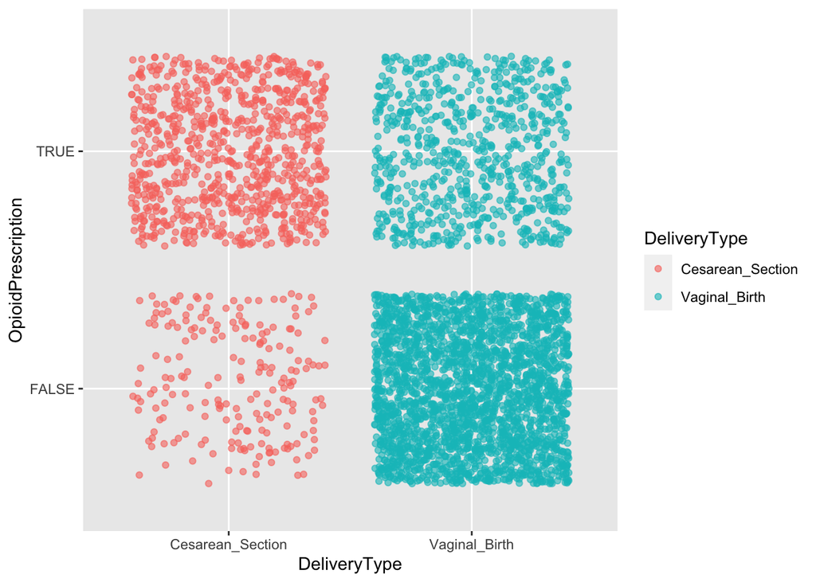

```r
# opioid prescription and delivery type
ggplot(visits, aes(DeliveryType, OpioidPrescription, color = DeliveryType)) +
  geom_jitter(alpha = 0.6)
```

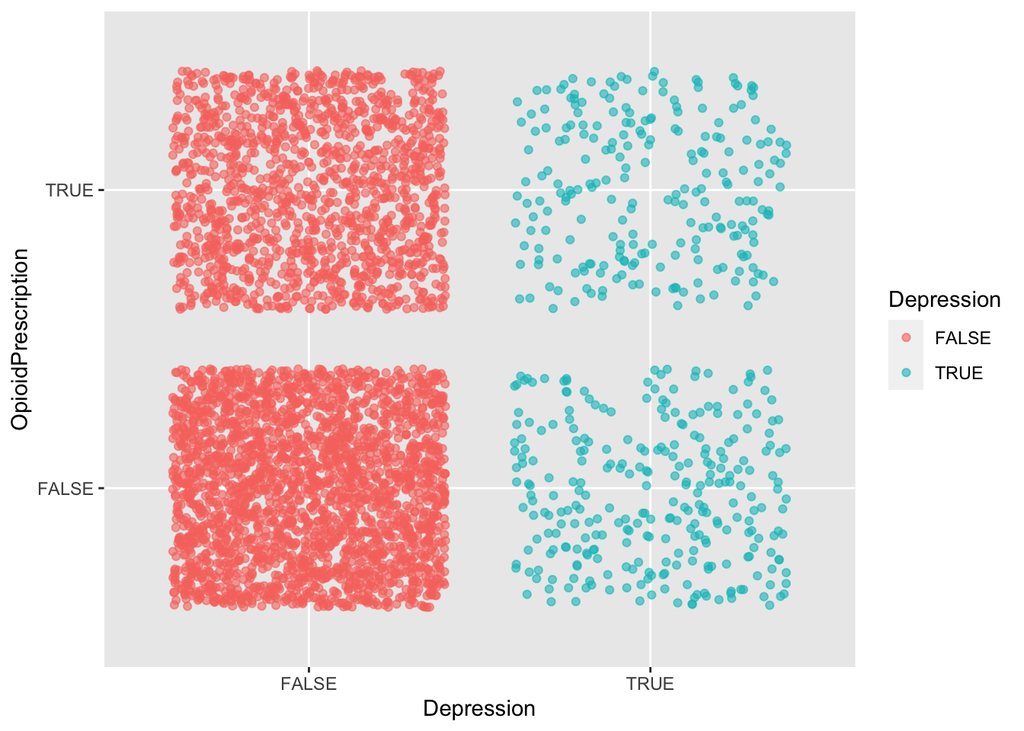

```r
# opioid prescription and depression
ggplot(visits, aes(Depression, OpioidPrescription, color = factor(Depression))) +
  geom_jitter(alpha = 0.6) +
  labs(color = "Depression")
```

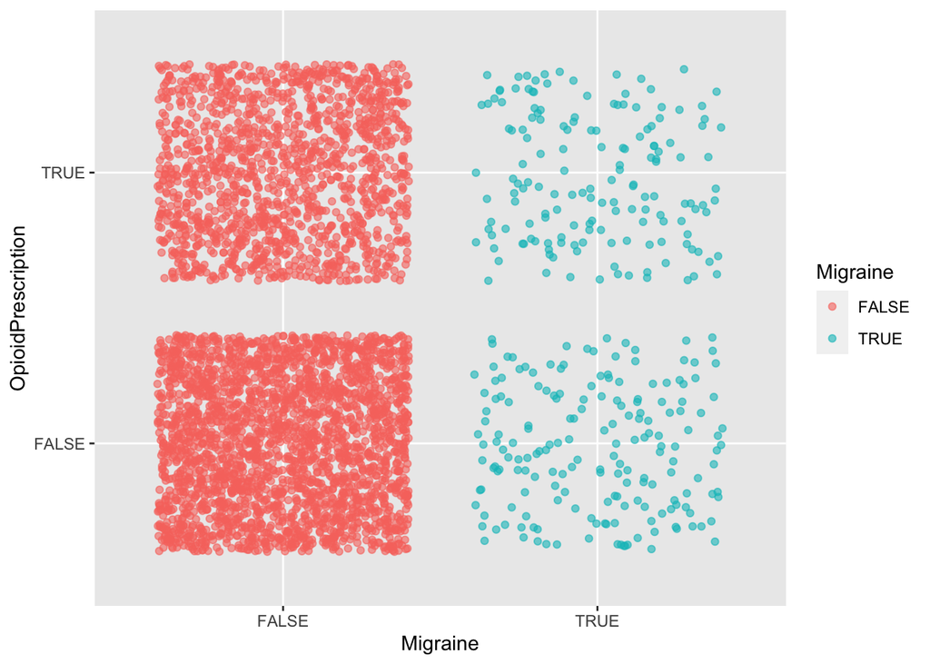

```r
# opioid prescription and migraine
ggplot(visits, aes(Migraine, OpioidPrescription, color = factor(Migraine))) +
  geom_jitter(alpha = 0.6) +
  labs(color = "Migraine")
```

Since the variables are binomial, we believed a geom_jitter plot would be best to show the distribution of responses. The depression and migraine plots show that although significantly more people were **not** prescribed opioids, the raw number of people that had depression/migraine was similar for both groups (people that were and were not prescribed opioids). This demonstrates how a greater percentage of people who were prescribed opioids had depression/migraine compared to the percentage of people who weren’t prescribed opioids that had depression/migraine. The plot comparing the delivery types reveals that more people who underwent a C-Section received an opioid prescription than not, while more people who underwent a Vaginal Birth were not prescribed opioids. Therefore, depression, migraines, and a C-Section seem to increase the odds of an opioid prescription, with a C-Section having the most significant impact on whether opioids are given.

### Statistical Models

```r
# make model using all variables to determine which variables are relevant
log <- glm(OpioidPrescription ~ Depression + Anxiety + Migraine + DeliveryType + ageAtBirth + PlanType, visits, family = "binomial")
summary(log)
```

```
##
## Call:
## glm(formula = OpioidPrescription ~ Depression + Anxiety + Migraine +
##     DeliveryType + ageAtBirth + PlanType, family = "binomial",
##     data = visits)
##
## Deviance Residuals:
##     Min       1Q   Median       3Q      Max
## -2.1443  -0.7450  -0.6622   0.7196   1.8034
##
## Coefficients:
##                             Estimate Std. Error z value Pr(>|z|)
## (Intercept)                1.4875617  0.2982688   4.987 6.12e-07 ***
## DepressionTRUE             0.5043241  0.1090233   4.626 3.73e-06 ***
## AnxietyTRUE                0.4358715  0.1378598   3.162  0.00157 **
## MigraineTRUE               0.5392197  0.1296996   4.157 3.22e-05 ***
## DeliveryTypeVaginal_Birth -2.6246036  0.0897801 -29.234  < 2e-16 ***
## ageAtBirth                -0.0001048  0.0105101  -0.010  0.99205
## PlanTypePPO               -0.2660665  0.0809874  -3.285  0.00102 **
## ---
## Signif. codes:  0 '***' 0.001 '**' 0.01 '*' 0.05 '.' 0.1 ' ' 1
##
## (Dispersion parameter for binomial family taken to be 1)
##
##     Null deviance: 5613.5  on 4246  degrees of freedom
## Residual deviance: 4475.7  on 4240  degrees of freedom
## AIC: 4489.7
##
## Number of Fisher Scoring iterations: 4
```

```r
# make model using C-Section as part of equation
log2 <- glm(OpioidPrescription ~ Depression + Anxiety + Migraine + Cesarean_Section + PlanType, visits2, family = "binomial")
summary(log2)
```

```
##
## Call:
## glm(formula = OpioidPrescription ~ Depression + Anxiety + Migraine +
##     Cesarean_Section + PlanType, family = "binomial", data = visits2)
##
## Deviance Residuals:
##     Min       1Q   Median       3Q      Max
## -2.1445  -0.7450  -0.6622   0.7197   1.8029
##
## Coefficients:
##                  Estimate Std. Error z value Pr(>|z|)
## (Intercept)      -1.13986    0.07415 -15.372  < 2e-16 ***
## Depression        0.50428    0.10893   4.629 3.67e-06 ***
## Anxiety           0.43585    0.13784   3.162  0.00157 **
## Migraine          0.53918    0.12963   4.159 3.19e-05 ***
## Cesarean_Section  2.62462    0.08976  29.239  < 2e-16 ***
## PlanTypePPO      -0.26609    0.08095  -3.287  0.00101 **
## ---
## Signif. codes:  0 '***' 0.001 '**' 0.01 '*' 0.05 '.' 0.1 ' ' 1
##
## (Dispersion parameter for binomial family taken to be 1)
##
##     Null deviance: 5613.5  on 4246  degrees of freedom
## Residual deviance: 4475.7  on 4241  degrees of freedom
## AIC: 4487.7
##
## Number of Fisher Scoring iterations: 4
```

```r
exp(coef(log2))
```

```
##      (Intercept)       Depression          Anxiety         Migraine
##        0.3198636        1.6557912        1.5462720        1.7145962
## Cesarean_Section      PlanTypePPO
##       13.7993438        0.7663704
```

## Report

In the final model, we included the variables of depression, anxiety, migraine, C-Section, and Plan Type. We created the model using a general linear model since the values in our data set were binary. Creating a logistic model with all of the variables in our data set indicated that the variables of depression, anxiety, migraine, delivery type, and plan type were significantly predictive of opioid prescription, while age at birth was not correlated. Since vaginal birth decreased the likelihood of an opioid prescription, we pivoted the data set to have columns for both Vaginal Birth and C-Section, so that the final model would show how much a C-Section increased the odds of receiving opioids.

Constructing a general linear model based on the relevant variables then exponentiating the coefficients, we can observe that having depression increases the odds of an opioid prescription by 1.66 times, anxiety 1.55 times, a migraine 1.71 times, the PPO plan type decreases the odds by a factor of 0.77, and most notably, having a C-Section procedure had 13.8 times the odds of receiving an opioid prescription compared to having a Vaginal Birth.

The graphs we created indicate that the ratio of having depression or a migraine for those prescribed opioids was higher than the ratio of having depression or a migraine for those not prescribed opioids. This agrees with our model since it indicates that those with depression or a migraine are more likely to be prescribed opioids. Furthermore, the significantly increased odds of opioid prescription when having a C-Section is demonstrated in the graph as those with a C-Section are much likelier to be prescribed opioids than not, while those with a Vaginal Birth are more likely to not be prescribed opioids. Overall, our model indicates that mental health diagnosis (both depression and anxiety) increases prescriptions of opioids post-partum.